# 蛋白质组与蛋白质分析

Author

Guangchuang Yu  
School of Basic Medical Sciences, Southern Medical University

Published

October 21, 2026

实验基于R语言环境，安装R语言，可参考：

- R语言安装

本实验以一组与**DNA损伤应答**相关的蛋白为例，用R完成一条”**从蛋白序列 → 基本属性 → 相互作用网络 → 功能富集 → 质谱定量（拓展）**”的分析链。涉及的蛋白：**p53 (TP53)、MDM2、BRCA1、BRCA2、ATM、CHK2、CDKN2A**。

## 一、蛋白序列下载与基本属性

### 用 rentrez 从 NCBI 下载序列

本节直接从 NCBI 下载这 7 个蛋白的 RefSeq 蛋白序列。给定蛋白的 RefSeq **accession**，用 `rentrez::entrez_fetch()` 获取 FASTA；NCBI 页面：https://www.ncbi.nlm.nih.gov/protein。`id` 接受向量，一次请求就能取回全部记录（返回**一个**拼好的多记录 FASTA 字符串），不必逐条循环。

```r
pload(rentrez)
```

```
── loading the package: rentrez ──
```

```r
acc <- c(TP53  = "NP_000537.3",
         MDM2  = "NP_002383.2",
         BRCA1 = "NP_009225.1",
         BRCA2 = "NP_001419006.1",
         ATM   = "NP_000042.3",
         CHEK2 = "NP_001005735.1",
         CDKN2A= "NP_000068.1")

if (file.exists("proteins_ncbi.fasta")) {
  message("proteins_ncbi.fasta 已存在，跳过 NCBI 下载")
} else {
  fa <- entrez_fetch(db = "protein", id = acc, rettype = "fasta")
  cat(fa, file = "proteins_ncbi.fasta")
}
```

```
proteins_ncbi.fasta 已存在，跳过 NCBI 下载
```

> 项目目录里另附两份离线文件：`proteins_ncbi.fasta` 是按上面 7 个 RefSeq accession 下载好的序列（与在线路径完全一致，NCBI 暂时不可用时直接用它）；`proteins.fasta` 来自 [UniProt](https://www.uniprot.org)，注意它选的是各自数据库的**代表序列**，MDM2（491 aa）与 CHEK2（543 aa，isoform a）与 RefSeq（497 aa / 586 aa，isoform c）不同，长度、分子量、等电点都会差一点。

```r
pload(Biostrings)
```

```
── loading the package: Biostrings ──
```

```r
seqs <- readAAStringSet("proteins_ncbi.fasta")
names(seqs) <- names(acc)   # 按下载顺序对应到基因名
seqs
```

```
AAStringSet object of length 7:
    width seq                                               names
[1]   393 MEEPQSDPSVEPPLSQETFSDLW...SKKGQSTSRHKKLMFKTEGPDSD TP53
[2]   497 MVRSRQMCNTNMSVPTDGAVTTS...KKRNKPCPVCRQPIQMIVLTYFP MDM2
[3]  1863 MDLSALRVEEVQNVINAMQKILE...SVALYQCQELDTYLIPQIPHSHY BRCA1
[4]  3418 MPIGSKERPTFFEIFKTRCNKAD...SSQASTEECEKNKQDTITTKKYI BRCA2
[5]  3056 MSLVLNDLLICCRQLEHDRATER...LLIQQAIDPKNLSRLFPGWKAWV ATM
[6]   586 MSRESDVEAQQSHGSSACSQPHG...RPREGEAEGAETTKRPAVCAAVL CHEK2
[7]   156 MEPAAGSSMEPSADWLATAAARG...AGGTRGSNHARIDAAEGPSDIPD CDKN2A
```

### 蛋白长度与氨基酸组成

```r
len <- width(seqs)
data.frame(gene = names(seqs), length = len)
```

```
    gene length
1   TP53    393
2   MDM2    497
3  BRCA1   1863
4  BRCA2   3418
5    ATM   3056
6  CHEK2    586
7 CDKN2A    156
```

```r
aa <- alphabetFrequency(seqs, baseOnly = TRUE)
rownames(aa) <- names(seqs)
round(aa[ , apply(aa, 2, function(x) sd(x) > 0)], 2)
```

```
         A   R   N   D  C   Q   E   G  H   I   L   K  M   F   P   S   T  W  Y
TP53    24  26  14  20 10  15  30  23 12   8  32  20 12  11  45  38  22  4  9
MDM2    15  23  18  36 19  28  56  21  9  20  36  31  9  11  23  67  25  4 14
BRCA1   84  76 121  85 44  97 198  87 49  77 156 137 30  49  96 224 111 10 31
BRCA2  174 110 230 171 76 154 293 122 83 187 281 322 45 136 149 381 220 20 79
ATM    157 152 137 156 89 154 233 119 72 179 389 214 79 123  98 234 158 38 96
CHEK2   36  29  20  29 14  24  51  33 14  27  56  40  7  21  30  63  32  6 18
CDKN2A  29  17   4  11  1   1  11  14  5   3  17   0  5   1  11   7   5  2  2
         V
TP53    18
MDM2    32
BRCA1  101
BRCA2  185
ATM    179
CHEK2   36
CDKN2A  10
```

### 分子量与等电点（`Peptides`）

用 `Peptides` 计算分子量与等电点。`pI()` 默认 `pKscale = "EMBOSS"`；与 [ExPASy Compute pI/Mw](https://web.expasy.org/compute_pi/)（Bjellqvist 标度）对照时会差 0.2–0.5。`mw()`、`pI()` 都直接吃整个字符向量、返回等长向量，不用逐条循环；但必须先 `as.character()`——把 `AAStringSet` 整个传进去会被当成一条序列，只算出水的质量。

```r
pload(Peptides)
```

```
── loading the package: Peptides ──
```

```r
res <- data.frame(
  gene = names(seqs),
  length = len,
  mw  = mw(as.character(seqs)),
  pI  = pI(as.character(seqs))
)
res[, c("mw", "pI")] <- round(res[, c("mw", "pI")], 1)
res
```

```
         gene length       mw  pI
TP53     TP53    393  43653.2 6.8
MDM2     MDM2    497  55990.8 4.4
BRCA1   BRCA1   1863 207720.8 5.1
BRCA2   BRCA2   3418 384230.3 6.7
ATM       ATM   3056 350687.5 6.8
CHEK2   CHEK2    586  65418.9 6.1
CDKN2A CDKN2A    156  16532.6 5.6
```

**思考**：BRCA2、ATM 为何”又长又重”？pI 与蛋白在细胞中的定位/功能有何关系？

## 二、蛋白相互作用网络（mechgraph + ggtangle）

`mechgraph` 从数据库下载并构建”机制证据图”（`mechgraph` 对象，含节点/边表）；`ggtangle` **直接接收 `mechgraph` 对象**——`ggplot(mg)` 自动把节点/边转成网络图，边用 `geom_edge()`，节点 `size` 自动为度（degree）。

> **数据文件**

| 文件 | 说明 |
| --- | --- |
| `proteins_ncbi.fasta` | 上表 7 个 RefSeq accession 的序列 |
| `proteins.fasta` | 同 7 个蛋白的 [UniProt](https://www.uniprot.org) 代表序列；MDM2 491 aa、CHEK2 543 aa（isoform a），与 RefSeq（497 / 586 aa，isoform c）不同 |
| `BIOGRID-MV-Physical-LATEST.tab3.zip` | BioGRID Multi-Validated **physical** 互作数据（35 MB 压缩 / 263 MB 解压），供 `mg_from_biogrid(file = ...)` 使用 |

`mg_from_string()` 可改用 **STRING**（`keytype = "symbol"`, `score_threshold = 700`），该数据需在线下载。

### 用 mechgraph 下载网络 + 聚焦到我们的基因

```r
pload(mechgraph)
```

```
── loading the package: mechgraph ──
```

```r
mg <- mg_from_biogrid(file = "BIOGRID-MV-Physical-LATEST.tab3.zip",
                      taxon_id = 9606, dataset = "mv_physical")
mg
```

```
<mechgraph>
  nodes: 12041
  edges: 101036
  node types: protein
  edge types: ppi
```

```r
genes <- c("TP53", "MDM2", "BRCA1", "BRCA2", "ATM", "CHEK2", "CDKN2A")
nd <- mg_nodes(mg)
ids <- nd$id[nd$label %in% genes]   # 节点 id 是 BIOGRID:xxxxx，基因名在 label 列
mg2 <- mg_induced_subgraph(mg, ids)
mg_nodes(mg2)
```

```
                 id    type  label taxon_id
18   BIOGRID:107140 protein  BRCA1     9606
203  BIOGRID:107142 protein  BRCA2     9606
237  BIOGRID:106962 protein    ATM     9606
245  BIOGRID:113010 protein   TP53     9606
2671 BIOGRID:107463 protein CDKN2A     9606
3142 BIOGRID:116369 protein  CHEK2     9606
3248 BIOGRID:110358 protein   MDM2     9606
```

```r
mg_edges(mg2)
```

```
                from             to type  source
5039  BIOGRID:106962 BIOGRID:106962  ppi BioGRID
5043  BIOGRID:106962 BIOGRID:107140  ppi BioGRID
5065  BIOGRID:106962 BIOGRID:110358  ppi BioGRID
5089  BIOGRID:106962 BIOGRID:113010  ppi BioGRID
5116  BIOGRID:106962 BIOGRID:116369  ppi BioGRID
6826  BIOGRID:107140 BIOGRID:107140  ppi BioGRID
6827  BIOGRID:107142 BIOGRID:107140  ppi BioGRID
6835  BIOGRID:107463 BIOGRID:107140  ppi BioGRID
6978  BIOGRID:107140 BIOGRID:113010  ppi BioGRID
7058  BIOGRID:116369 BIOGRID:107140  ppi BioGRID
7166  BIOGRID:107142 BIOGRID:107142  ppi BioGRID
7186  BIOGRID:107142 BIOGRID:113010  ppi BioGRID
7203  BIOGRID:116369 BIOGRID:107142  ppi BioGRID
11932 BIOGRID:107463 BIOGRID:107463  ppi BioGRID
```

[output cut: 54 more lines]

> BioGRID 同一对蛋白之间常有多条”证据边”，还可能有反向重复对与自环，画图前可先化简，观察会更清晰： `g <- igraph::simplify(igraph::graph_from_data_frame(mg_edges(mg2)[, c("from","to")], directed = FALSE))`

### 用 ggtangle 直接可视化 mechgraph

```r
pload(ggtangle)
```

```
── loading the package: ggtangle ──
```

```
ggtangle v0.1.4 Learn more at https://yulab-smu.top/
```

```r
pload(ggplot2)
```

```
── loading the package: ggplot2 ──
```

```r
pload(shadowtext)
```

```
── loading the package: shadowtext ──
```

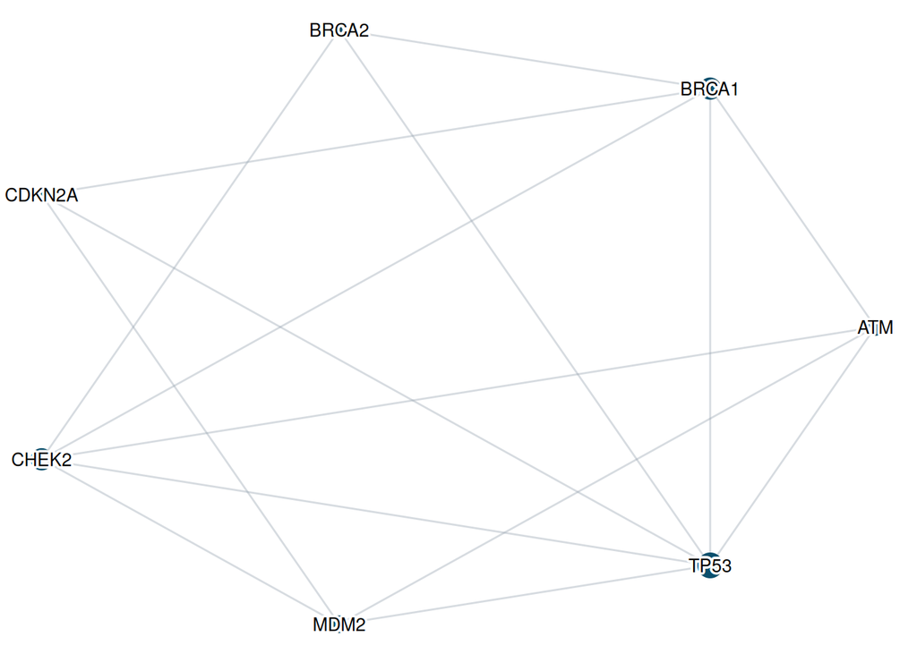

```r
ggplot(mg2, layout = "circular") +
    geom_edge(alpha = .4, color = "#9AA5B1") +
    geom_point(aes(size = size), color = "#0B4F6C", show.legend = FALSE) +
    geom_shadowtext(aes(label = name), color = "black",
                    bg.color = "white", bg.r = 0.18, size = 3.5) +
    theme_void() +
    theme(plot.background = element_rect(fill = "white", color = NA))
```

**思考**：图中最大的节点（度最高）是哪个蛋白？为何它在 DNA 损伤应答中如此核心？（这组基因在 BioGRID 中高度连通，TP53 是最核心的 hub。）

> 需要具体的度数值时，可用 `igraph::as.igraph(mg2)` 把 `mechgraph` 转成 `igraph`（节点/边信息会作为 igraph 属性保留）。注意 BioGRID 的 physical 数据里**自相互作用**（同源二聚体）也是一条边，igraph 会把自环算作 2 度；算度数前先用 `g <- igraph::simplify(igraph::as.igraph(mg2), remove.multiple = TRUE, remove.loops = TRUE)`，再 `igraph::degree(g)`。若改用 STRING，只需把下载语句换成：`mg <- mg_from_string(taxon_id = 9606, keytype = "symbol", score_threshold = 700)`。

## 三、功能富集分析

这组蛋白”一起做什么”？用它们的基因做 GO 富集。

```r
entrez <- c(TP53 = 7157, MDM2 = 4193, BRCA1 = 672, BRCA2 = 675,
            ATM = 472, CHEK2 = 11200, CDKN2A = 1029)
```

```r
pload(clusterProfiler)
```

```
── loading the package: clusterProfiler ──
```

```
clusterProfiler v4.21.3 Learn more at https://yulab-smu.top/contribution-knowledge-mining/

G Yu. Thirteen years of clusterProfiler. The Innovation. 2024,
5(6):100722
```

```r
pload(org.Hs.eg.db)
```

```
── loading the package: org.Hs.eg.db ──
```

```r
x <- enrichGO(entrez, OrgDb = org.Hs.eg.db, ont = "BP",
              pvalueCutoff = 0.2, qvalueCutoff = 0.2, readable = TRUE)
x
```

```
#
# over-representation test
#
#...@organism    Homo sapiens
#...@ontology    BP
#...@keytype     ENTREZID
#...@gene    chr [1:7] "7157" "4193" "672" "675" "472" "11200" "1029"
#...pvalues adjusted by 'BH' with cutoff < 0.2
#...629 enriched terms found
'data.frame':   629 obs. of  13 variables:
 $ ID            : chr  "GO:0042770" "GO:0090399" "GO:0071479" "GO:0030330" ...
 $ Description   : chr  "signal transduction in response to DNA damage" "replicative senescence" "cellular response to ionizing radiation" "DNA damage response, signal transduction by p53 class mediator" ...
 $ GeneRatio     : chr  "7/7" "4/7" "5/7" "5/7" ...
 $ BgRatio       : chr  "185/18842" "14/18842" "63/18842" "72/18842" ...
 $ RichFactor    : num  0.0378 0.2857 0.0794 0.0694 0.0459 ...
 $ FoldEnrichment: num  102 769 214 187 123 ...
 $ oddsRatio     : num  Inf 2510 809 700 450 ...
 $ zScore        : num  26.6 55.4 32.6 30.5 24.7 ...
 $ pvalue        : num  7.85e-15 6.66e-12 7.42e-12 1.48e-11 1.23e-10 ...
 $ p.adjust      : num  4.94e-12 1.56e-09 1.56e-09 2.32e-09 1.55e-08 ...
 $ qvalue        : num  1.09e-12 3.44e-10 3.44e-10 5.13e-10 3.42e-09 ...
 $ geneID        : chr  "TP53/MDM2/BRCA1/BRCA2/ATM/CHEK2/CDKN2A" "TP53/ATM/CHEK2/CDKN2A" "TP53/MDM2/BRCA1/BRCA2/ATM" "TP53/MDM2/ATM/CHEK2/CDKN2A" ...
 $ Count         : int  7 4 5 5 5 5 5 6 5 5 ...
#...Citation
```

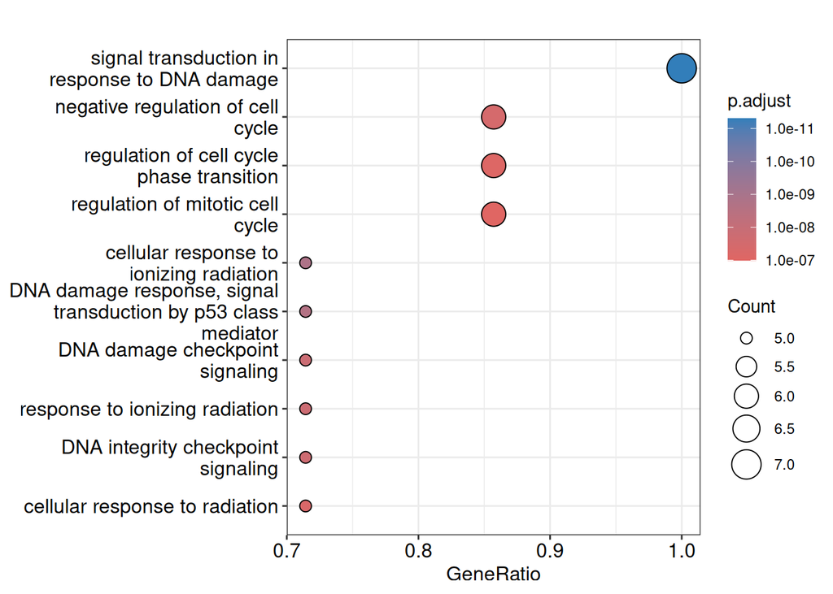

```r
dotplot(x)
```

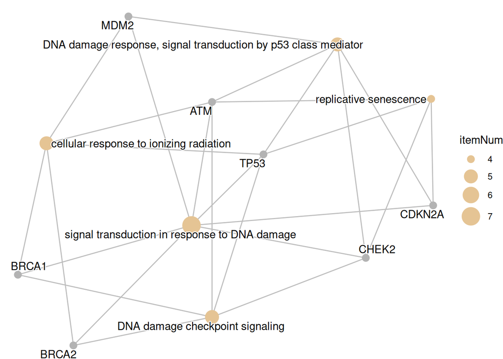

```r
cnetplot(x, showCategory = 5)
```

**思考**：富集到的最显著生物学过程是什么？与你对这组蛋白功能的直觉一致吗？

## 四、拓展：质谱定量分析（MSstats）

如果拿到质谱（如 MaxQuant）的定量数据，可用 `MSstats` 做蛋白水平的差异丰度分析。

### 用 MSstats 做蛋白差异丰度分析

```r
pload(MSstats)
```

```
── loading the package: MSstats ──
```

```r
data(DDARawData)   # 内置示例：label-free DDA 掺入（spike-in）实验，6 蛋白 / 6 条件（Mueller et al. 2007，latin square 设计）
head(DDARawData)
```

```
  ProteinName PeptideSequence PrecursorCharge FragmentIon ProductCharge
1      bovine     S.PVDIDTK_5               5          NA            NA
2      bovine     S.PVDIDTK_5               5          NA            NA
3      bovine     S.PVDIDTK_5               5          NA            NA
4      bovine     S.PVDIDTK_5               5          NA            NA
5      bovine     S.PVDIDTK_5               5          NA            NA
6      bovine     S.PVDIDTK_5               5          NA            NA
  IsotopeLabelType Condition BioReplicate Run Intensity
1                L        C1            1   1   2636792
2                L        C1            1   2   1992418
3                L        C1            1   3   1982146
4                L        C2            1   4   5019594
5                L        C2            1   5   4560468
6                L        C2            1   6   3627849
```

```r
dim(DDARawData)
```

```
[1] 2070   10
```

```r
table(DDARawData$ProteinName)
```

```
   bovine   chicken cyc_horse myg_horse    rabbit     yeast
      252       198       576       216       558       270
```

```r
processed <- dataProcess(DDARawData)   # 肽段→蛋白水平汇总
```

```
INFO  [2026-10-21 11:37:34] ** Features with one or two measurements across runs are removed.
INFO  [2026-10-21 11:37:34] ** Fractionation handled.
INFO  [2026-10-21 11:37:34] ** Updated quantification data to make balanced design. Missing values are marked by NA
INFO  [2026-10-21 11:37:34] ** Log2 intensities under cutoff = 13.456  were considered as censored missing values.
INFO  [2026-10-21 11:37:34] ** Log2 intensities = NA were considered as censored missing values.
INFO  [2026-10-21 11:37:34] ** Use top100 features that have highest average of log2(intensity) across runs.
INFO  [2026-10-21 11:37:34]
 # proteins: 6
 # peptides per protein: 11-32
 # features per peptide: 1-1
INFO  [2026-10-21 11:37:34]
                    C1 C2 C3 C4 C5 C6
             # runs  3  3  3  3  3  3
    # bioreplicates  1  1  1  1  1  1
 # tech. replicates  3  3  3  3  3  3
INFO  [2026-10-21 11:37:34] Some features are completely missing in at least one condition:
 -.PHSHPALTPEQK_35_35_NA_NA,
 A.DIAGHGQEVLIR_321_321_NA_NA,
 A.PGFTYTDANK_129_129_NA_NA,
 A.PGFTYTDANK_130_130_NA_NA,
 A.PGFTYTDANK_131_131_NA_NA ...
INFO  [2026-10-21 11:37:34]  == Start the summarization per subplot...

INFO  [2026-10-21 11:37:34]  == Summarization is done.
```

```r
names(processed)
```

```
[1] "FeatureLevelData" "ProteinLevelData" "SummaryMethod"
```

构造对比矩阵（比较 C6 与 C4 两个条件；latin square 设计下各蛋白浓度走向不同，log2FC 有正有负）：

```r
lv <- c("C1", "C2", "C3", "C4", "C5", "C6")
cm <- matrix(0, nrow = 1, ncol = 6, dimnames = list("C6-vs-C4", lv))
cm[1, "C4"] <- -1
cm[1, "C6"] <- 1

cmp <- groupComparison(contrast.matrix = cm, data = processed)
```

```
INFO  [2026-10-21 11:37:34]  == Start to test and get inference in whole plot ...

INFO  [2026-10-21 11:37:34]  == Comparisons for all proteins are done.
```

```r
res <- cmp$ComparisonResult   # 每蛋白的 log2FC、p 值等
res
```

```
    Protein    Label    log2FC        SE     Tvalue DF       pvalue
1    bovine C6-vs-C4  3.644656 0.4245943   8.583853 11 3.322944e-06
2   chicken C6-vs-C4 -5.108220 0.2205455 -23.161746 12 2.498091e-11
3 cyc_horse C6-vs-C4  2.691865 0.1955787  13.763586 12 1.035056e-08
4 myg_horse C6-vs-C4  3.175654 0.2807086  11.312993 12 9.300920e-08
5    rabbit C6-vs-C4  2.020085 0.2209612   9.142261 12 9.352836e-07
6     yeast C6-vs-C4 -6.366990 0.3134408 -20.313216 12 1.163274e-10
    adj.pvalue issue MissingPercentage ImputationPercentage
1 3.322944e-06    NA        0.40476190           0.40476190
2 1.498854e-10    NA        0.24242424           0.24242424
3 2.070113e-08    NA        0.49479167           0.49479167
4 1.395138e-07    NA        0.22222222           0.22222222
5 1.122340e-06    NA        0.09677419           0.09677419
6 3.489822e-10    NA        0.42222222           0.42222222
```

```r
pload(ggplot2)
```

```
── loading the package: ggplot2 ──
```

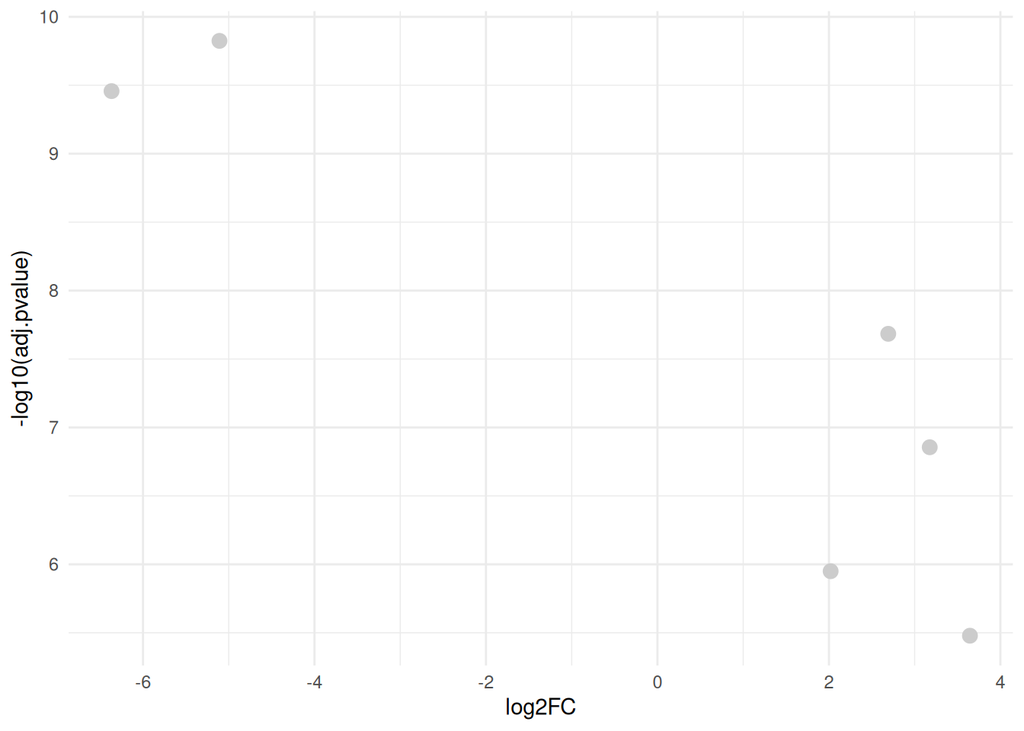

```r
ggplot(res, aes(log2FC, -log10(adj.pvalue),
                color = adj.pvalue < 0.05 & abs(log2FC) > 1)) +
    geom_point(size = 3) +
    scale_color_manual(values = c("grey80", "firebrick")) +
    theme_minimal() +
    theme(legend.position = "none")
```

下面用 `ivolcano` 出交互式版本，鼠标悬停可看数值：

```r
pload(ivolcano)
```

```
── loading the package: ivolcano ──
```

```r
vdat <- data.frame(gene      = res$Protein,
                   logFC     = res$log2FC,
                   adj.P.Val = res$adj.pvalue,
                   pvalue    = res$pvalue,
                   SE        = res$SE)
ivolcano(vdat, logFC_col = "logFC", pval_col = "adj.P.Val", gene_col = "gene",
         title = "C6 vs C4 (MSstats, DDARawData)",
         interactive = TRUE)
```

[interactive chart not shown]

> 实际的质谱数据可先用 `MaxQtoMSstatsFormat(evidence, annotation)` 将 MaxQuant 的 `evidence.txt` 转成 MSstats 格式，再走上面 `dataProcess()` + `groupComparison()` 流程。

**思考**：质谱定量的”差异分析”思路与转录组的 `DESeq2`/`limma` 有何异同？

## 五、小结

- **R 分析链**：序列下载（`rentrez`）→ 基本属性（`Biostrings`/`Peptides`）→ 互作网络（`mechgraph` + `ggtangle`）→ 功能富集（`clusterProfiler`）→ 定量（`MSstats`）。
- 进一步可拓展：蛋白修饰位点分析、序列 Motif 检索、用 `igraph::as.igraph()` 把 `mechgraph` 交给别的 graph 工具进一步分析等。
- **注意**：第 4 节的 `DDARawData` 每个条件只有 1 个生物学重复（3 个技术重复），MSstats 用技术重复估计误差，这里的 p 值**不能**当生物学显著性读。